# HW 06 Part 1: Complete the sections

Christina Beauford

28 December 2018

- Change “your name” in the YAML header above to your name.
- As usual, enter the examples in code chunks and run them, unless told otherwise.

```r
library(tidyverse)
library(smatr)
```

##Coding Style

```r
file_path <- "data/"
```

[figure not shown]

```r
data(iris)
ggplot(data = iris, mapping = aes(x = Petal.Length, y = Sepal.Length)) +
  geom_point(mapping = aes(color = Species, shape = Species)) +
  geom_smooth(mapping = aes(color = Species))
```

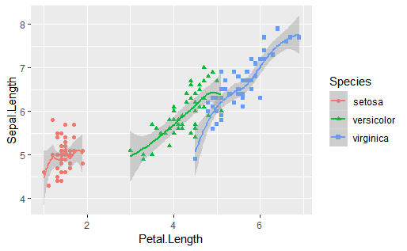

```r
ggplot(data = iris,
       aes(x = Petal.Length,
           y = Sepal.Length)) +
  geom_point(aes(color = Species,
                 shape = Species)) +
  geom_smooth(aes(color = Species))
```

##Wrangling II

## Chapter 5: Data transformation

Read [R4ds Chapter 5: Data transformation](https://r4ds.had.co.nz/transform.html), sections 5-7.

```r
library(nycflights13)
library(tidyverse)
```

### Section 5.5: Add new variables with `mutate()`

Type and run all of the examples.

Pay careful attention to the useful creation functions in section 5.5.1.

Do not answer any of the questions.

```r
flights_sml <- select(flights,
  year:day,
  ends_with("delay"),
  distance,
  air_time
)
```

```r
mutate(flights_sml,
  gain = dep_delay - arr_delay,
  speed = distance / air_time * 60
)
```

| year | month | day | dep_delay | arr_delay | distance | air_time | gain | speed |
| --- | --- | --- | --- | --- | --- | --- | --- | --- |
| 2013 | 1 | 1 | 2 | 11 | 1400 | 227 | -9 | 370.0441 |
| 2013 | 1 | 1 | 4 | 20 | 1416 | 227 | -16 | 374.2731 |
| 2013 | 1 | 1 | 2 | 33 | 1089 | 160 | -31 | 408.3750 |
| 2013 | 1 | 1 | -1 | -18 | 1576 | 183 | 17 | 516.7213 |
| 2013 | 1 | 1 | -6 | -25 | 762 | 116 | 19 | 394.1379 |
| 2013 | 1 | 1 | -4 | 12 | 719 | 150 | -16 | 287.6000 |
| 2013 | 1 | 1 | -5 | 19 | 1065 | 158 | -24 | 404.4304 |
| 2013 | 1 | 1 | -3 | -14 | 229 | 53 | 11 | 259.2453 |
| 2013 | 1 | 1 | -3 | -8 | 944 | 140 | 5 | 404.5714 |
| 2013 | 1 | 1 | -2 | 8 | 733 | 138 | -10 | 318.6957 |

[output cut: 990 more lines]

mutate() adds new columns that are functions of existing columns. It adds the columns at the end of the dataset.

```r
mutate(flights_sml,
  gain = dep_delay - arr_delay,
  hours = air_time / 60,
  gain_per_hour = gain / hours
)
```

| year | month | day | dep_delay | arr_delay | distance | air_time | gain | hours | gain_per_hour |
| --- | --- | --- | --- | --- | --- | --- | --- | --- | --- |
| 2013 | 1 | 1 | 2 | 11 | 1400 | 227 | -9 | 3.7833333 | -2.3788546 |
| 2013 | 1 | 1 | 4 | 20 | 1416 | 227 | -16 | 3.7833333 | -4.2290749 |
| 2013 | 1 | 1 | 2 | 33 | 1089 | 160 | -31 | 2.6666667 | -11.6250000 |
| 2013 | 1 | 1 | -1 | -18 | 1576 | 183 | 17 | 3.0500000 | 5.5737705 |
| 2013 | 1 | 1 | -6 | -25 | 762 | 116 | 19 | 1.9333333 | 9.8275862 |
| 2013 | 1 | 1 | -4 | 12 | 719 | 150 | -16 | 2.5000000 | -6.4000000 |
| 2013 | 1 | 1 | -5 | 19 | 1065 | 158 | -24 | 2.6333333 | -9.1139241 |
| 2013 | 1 | 1 | -3 | -14 | 229 | 53 | 11 | 0.8833333 | 12.4528302 |
| 2013 | 1 | 1 | -3 | -8 | 944 | 140 | 5 | 2.3333333 | 2.1428571 |
| 2013 | 1 | 1 | -2 | 8 | 733 | 138 | -10 | 2.3000000 | -4.3478261 |

[output cut: 990 more lines]

Refers to columns that were just created with mutate().

```r
transmute(flights,
  gain = dep_delay - arr_delay,
  hours = air_time / 60,
  gain_per_hour = gain / hours
)
```

| gain | hours | gain_per_hour |
| --- | --- | --- |
| -9 | 3.7833333 | -2.3788546 |
| -16 | 3.7833333 | -4.2290749 |
| -31 | 2.6666667 | -11.6250000 |
| 17 | 3.0500000 | 5.5737705 |
| 19 | 1.9333333 | 9.8275862 |
| -16 | 2.5000000 | -6.4000000 |
| -24 | 2.6333333 | -9.1139241 |
| 11 | 0.8833333 | 12.4528302 |
| 5 | 2.3333333 | 2.1428571 |
| -10 | 2.3000000 | -4.3478261 |

[output cut: 990 more lines]

transmutate() keeps only the new columns created.

```r
transmute(flights,
  dep_time,
  hour = dep_time %/% 100,
  minute = dep_time %% 100
)
```

| dep_time | hour | minute |
| --- | --- | --- |
| 517 | 5 | 17 |
| 533 | 5 | 33 |
| 542 | 5 | 42 |
| 544 | 5 | 44 |
| 554 | 5 | 54 |
| 554 | 5 | 54 |
| 555 | 5 | 55 |
| 557 | 5 | 57 |
| 557 | 5 | 57 |
| 558 | 5 | 58 |

[output cut: 990 more lines]

Showing that the mutate() variables must be vectorized, they can be used with arithmetic functions. %/% is integer division (used in this code chunk).

```r
(x <- 1:10)
```

```
 [1]  1  2  3  4  5  6  7  8  9 10
```

```r
lag(x)
```

```
 [1] NA  1  2  3  4  5  6  7  8  9
```

```r
lead(x)
```

```
 [1]  2  3  4  5  6  7  8  9 10 NA
```

lead and lag allow you to refer to leading and lagging values. Most useful when used with group_by().

```r
x
```

```
 [1]  1  2  3  4  5  6  7  8  9 10
```

```r
cumsum(x)
```

```
 [1]  1  3  6 10 15 21 28 36 45 55
```

```r
cummean(x)
```

```
 [1] 1.0 1.5 2.0 2.5 3.0 3.5 4.0 4.5 5.0 5.5
```

“cumulative and rolling aggregates”. cumsum, cummean are cumulative functions.

```r
y <- c(1, 2, 2, NA, 3, 4)
min_rank(y)
```

```
[1]  1  2  2 NA  4  5
```

```r
min_rank(desc(y))
```

```
[1]  5  3  3 NA  2  1
```

Ranking. min_rank is the usual type of ranking (1st, 2nd, 3rd…); gives the smallest values first. desc gives largest values first (descending).

```r
row_number(y)
```

```
[1]  1  2  3 NA  4  5
```

```r
dense_rank(y)
```

```
[1]  1  2  2 NA  3  4
```

```r
percent_rank(y)
```

```
[1] 0.00 0.25 0.25   NA 0.75 1.00
```

```r
cume_dist(y)
```

```
[1] 0.2 0.6 0.6  NA 0.8 1.0
```

### Section 5.6: Grouped summaries with `summarise()`

Read and run all of the examples. Pay careful attention to the useful summary functions. Unless you really like baseball, skip the baseball part of 5.6.3.

```r
summarise(flights, delay = mean(dep_delay, na.rm = TRUE))
```

| delay |
| --- |
| 12.63907 |

```r
by_day <- group_by(flights, year, month, day)
summarise(by_day, delay = mean(dep_delay, na.rm = TRUE))
```

| year | month | day | delay |
| --- | --- | --- | --- |
| 2013 | 1 | 1 | 11.54892601 |
| 2013 | 1 | 2 | 13.85882353 |
| 2013 | 1 | 3 | 10.98783186 |
| 2013 | 1 | 4 | 8.95159516 |
| 2013 | 1 | 5 | 5.73221757 |
| 2013 | 1 | 6 | 7.14801444 |
| 2013 | 1 | 7 | 5.41720430 |
| 2013 | 1 | 8 | 2.55307263 |
| 2013 | 1 | 9 | 2.27647715 |
| 2013 | 1 | 10 | 2.84499462 |

[output cut: 355 more lines]

```r
by_dest <- group_by(flights, dest)
delay <- summarise(by_dest,
  count = n(),
  dist = mean(distance, na.rm = TRUE),
  delay = mean(arr_delay, na.rm = TRUE)
)
delay <- filter(delay, count > 20, dest != "HNL")
```

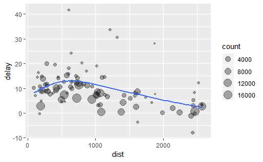

```r
ggplot(data = delay, mapping = aes(x = dist, y = delay)) +
  geom_point(aes(size = count), alpha = 1/3) +
  geom_smooth(se = FALSE)
```

```r
delays <- flights %>%
  group_by(dest) %>%
  summarise(
    count = n(),
    dist = mean(distance, na.rm = TRUE),
    delay = mean(arr_delay, na.rm = TRUE)
  ) %>%
  filter(count > 20, dest != "HNL")
```

```r
flights %>%
  group_by(year, month, day) %>%
  summarise(mean = mean(dep_delay))
```

| year | month | day | mean |
| --- | --- | --- | --- |
| 2013 | 1 | 1 | NA |
| 2013 | 1 | 2 | NA |
| 2013 | 1 | 3 | NA |
| 2013 | 1 | 4 | NA |
| 2013 | 1 | 5 | NA |
| 2013 | 1 | 6 | NA |
| 2013 | 1 | 7 | NA |
| 2013 | 1 | 8 | NA |
| 2013 | 1 | 9 | NA |
| 2013 | 1 | 10 | NA |

[output cut: 355 more lines]

```r
flights %>%
  group_by(year, month, day) %>%
  summarise(mean = mean(dep_delay, na.rm = TRUE))
```

| year | month | day | mean |
| --- | --- | --- | --- |
| 2013 | 1 | 1 | 11.54892601 |
| 2013 | 1 | 2 | 13.85882353 |
| 2013 | 1 | 3 | 10.98783186 |
| 2013 | 1 | 4 | 8.95159516 |
| 2013 | 1 | 5 | 5.73221757 |
| 2013 | 1 | 6 | 7.14801444 |
| 2013 | 1 | 7 | 5.41720430 |
| 2013 | 1 | 8 | 2.55307263 |
| 2013 | 1 | 9 | 2.27647715 |
| 2013 | 1 | 10 | 2.84499462 |

[output cut: 355 more lines]

```r
not_cancelled <- flights %>%
  filter(!is.na(dep_delay), !is.na(arr_delay))
```

```r
not_cancelled %>%
  group_by(year, month, day) %>%
  summarise(mean = mean(dep_delay))
```

| year | month | day | mean |
| --- | --- | --- | --- |
| 2013 | 1 | 1 | 11.43561974 |
| 2013 | 1 | 2 | 13.67780172 |
| 2013 | 1 | 3 | 10.90777778 |
| 2013 | 1 | 4 | 8.96585903 |
| 2013 | 1 | 5 | 5.73221757 |
| 2013 | 1 | 6 | 7.14595899 |
| 2013 | 1 | 7 | 5.41720430 |
| 2013 | 1 | 8 | 2.55829596 |
| 2013 | 1 | 9 | 2.30123180 |
| 2013 | 1 | 10 | 2.84499462 |

[output cut: 355 more lines]

```r
delays <- not_cancelled %>%
  group_by(tailnum) %>%
  summarise(
    delay = mean(arr_delay)
  )
```

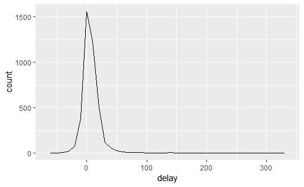

```r
ggplot(data = delays, mapping = aes(x = delay)) +
  geom_freqpoly(binwidth = 10)
```

```r
delays <- not_cancelled %>%
  group_by(tailnum) %>%
  summarise(
    delay = mean(arr_delay, na.rm = TRUE),
    n = n()
  )
```

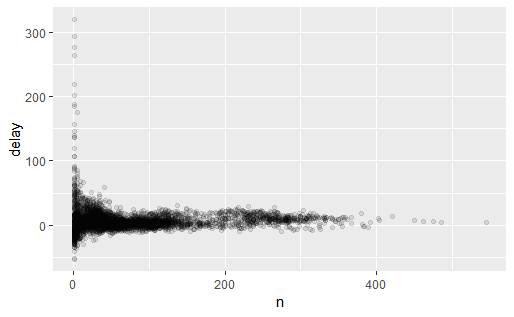

```r
ggplot(data = delays, mapping = aes(x = n, y = delay)) +
  geom_point(alpha = 1/10)
```

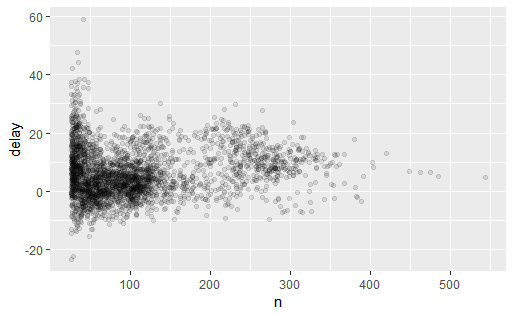

```r
delays %>%
  filter(n > 25) %>%
  ggplot(mapping = aes(x = n, y = delay)) +
    geom_point(alpha = 1/10)
```

### Section 5.7: Grouped mutates (and filters)

Read and run all of the examples.

```r
flights_sml %>%
  group_by(year, month, day) %>%
  filter(rank(desc(arr_delay)) < 10)
```

| year | month | day | dep_delay | arr_delay | distance | air_time |
| --- | --- | --- | --- | --- | --- | --- |
| 2013 | 1 | 1 | 853 | 851 | 184 | 41 |
| 2013 | 1 | 1 | 290 | 338 | 1134 | 213 |
| 2013 | 1 | 1 | 260 | 263 | 266 | 46 |
| 2013 | 1 | 1 | 157 | 174 | 213 | 60 |
| 2013 | 1 | 1 | 216 | 222 | 708 | 121 |
| 2013 | 1 | 1 | 255 | 250 | 589 | 115 |
| 2013 | 1 | 1 | 285 | 246 | 1085 | 146 |
| 2013 | 1 | 1 | 192 | 191 | 199 | 44 |
| 2013 | 1 | 1 | 379 | 456 | 1092 | 222 |
| 2013 | 1 | 2 | 224 | 207 | 550 | 94 |

[output cut: 990 more lines]

```r
popular_dests <- flights %>%
  group_by(dest) %>%
  filter(n() > 365)
popular_dests
```

| year | month | day | dep_time | sched_dep_time | dep_delay | arr_time | sched_arr_time | arr_delay | carrier | flight | tailnum | origin | dest | air_time | distance | hour | minute | time_hour |
| --- | --- | --- | --- | --- | --- | --- | --- | --- | --- | --- | --- | --- | --- | --- | --- | --- | --- | --- |
| 2013 | 1 | 1 | 517 | 515 | 2 | 830 | 819 | 11 | UA | 1545 | N14228 | EWR | IAH | 227 | 1400 | 5 | 15 | 2013-01-01 05:00:00 |
| 2013 | 1 | 1 | 533 | 529 | 4 | 850 | 830 | 20 | UA | 1714 | N24211 | LGA | IAH | 227 | 1416 | 5 | 29 | 2013-01-01 05:00:00 |
| 2013 | 1 | 1 | 542 | 540 | 2 | 923 | 850 | 33 | AA | 1141 | N619AA | JFK | MIA | 160 | 1089 | 5 | 40 | 2013-01-01 05:00:00 |
| 2013 | 1 | 1 | 544 | 545 | -1 | 1004 | 1022 | -18 | B6 | 725 | N804JB | JFK | BQN | 183 | 1576 | 5 | 45 | 2013-01-01 05:00:00 |
| 2013 | 1 | 1 | 554 | 600 | -6 | 812 | 837 | -25 | DL | 461 | N668DN | LGA | ATL | 116 | 762 | 6 | 0 | 2013-01-01 06:00:00 |
| 2013 | 1 | 1 | 554 | 558 | -4 | 740 | 728 | 12 | UA | 1696 | N39463 | EWR | ORD | 150 | 719 | 5 | 58 | 2013-01-01 05:00:00 |
| 2013 | 1 | 1 | 555 | 600 | -5 | 913 | 854 | 19 | B6 | 507 | N516JB | EWR | FLL | 158 | 1065 | 6 | 0 | 2013-01-01 06:00:00 |
| 2013 | 1 | 1 | 557 | 600 | -3 | 709 | 723 | -14 | EV | 5708 | N829AS | LGA | IAD | 53 | 229 | 6 | 0 | 2013-01-01 06:00:00 |
| 2013 | 1 | 1 | 557 | 600 | -3 | 838 | 846 | -8 | B6 | 79 | N593JB | JFK | MCO | 140 | 944 | 6 | 0 | 2013-01-01 06:00:00 |
| 2013 | 1 | 1 | 558 | 600 | -2 | 753 | 745 | 8 | AA | 301 | N3ALAA | LGA | ORD | 138 | 733 | 6 | 0 | 2013-01-01 06:00:00 |

[output cut: 990 more lines]

```r
popular_dests %>%
  filter(arr_delay > 0) %>%
  mutate(prop_delay = arr_delay / sum(arr_delay)) %>%
  select(year:day, dest, arr_delay, prop_delay)
```

| year | month | day | dest | arr_delay | prop_delay |
| --- | --- | --- | --- | --- | --- |
| 2013 | 1 | 1 | IAH | 11 | 1.106740e-04 |
| 2013 | 1 | 1 | IAH | 20 | 2.012255e-04 |
| 2013 | 1 | 1 | MIA | 33 | 2.350026e-04 |
| 2013 | 1 | 1 | ORD | 12 | 4.239594e-05 |
| 2013 | 1 | 1 | FLL | 19 | 9.377853e-05 |
| 2013 | 1 | 1 | ORD | 8 | 2.826396e-05 |
| 2013 | 1 | 1 | LAX | 7 | 3.444441e-05 |
| 2013 | 1 | 1 | DFW | 31 | 2.817951e-04 |
| 2013 | 1 | 1 | ATL | 12 | 3.996017e-05 |
| 2013 | 1 | 1 | DTW | 16 | 1.157257e-04 |

[output cut: 990 more lines]